# BMIN503/EPID600 Final Project

Elizabeth Mahanna Gabrielli, MD

### Overview

This project will be investigating 6 month outcomes in stroke patients who are discharged from the hospital to a nursing home. We will formulate 3 models. One model will address the question: What factors predict if these patients survive to 6 months? The second model will address the question: What factors predict if these patients improve their living situation (either living at home, a relatives or a residential community) or remain in the nursing home? The third model will address the question: What factors predict their level of function? Are they dependent or not-dependent?

https://github.com/emahannagabrielli/BMIN503_Final_Project

Faculty advisors:

Dr. Monisha Kumar, Associate Professor Department of Neurology. At first I was going to have 2 research questions about final functional outcome and final living place, which each included survival as an outcome. After, discussing with Dr.Kumar, predicting survival on its own is an important question. Then we decided because we will be looking at survival separately, we will only investigate final functional outcome and final living place for patients who survived 6 months after discharge. In addition, Dr. Kumar helped me decide how to group the final outcomes into clinical relevant groups.

Dr. Rebecca Hubbard, Associate Professor of Biostatistics and Todd Miano helped me in determing how to analyze the data. Dr. Hubbard at first suggested I use multinominal regression when my original research questions had 3 categorial variables with the mlogit(). After we changed questions, she suggested multivariate linear regression with the glm() function in R. She helped me decide how to group patients and which data to remove because of incomplete outcomes or not a clear outcome.

### Introduction

Acute stroke is a common and highly morbid disease. Worldwide it is the second most common cause of mortality and third most common cause of disability. More than 7 million people in the United States survive a stroke each year. Improvements in acute stroke treatment such as intravenous tPA and thombectomy have greatly decreased stroke mortality and disabilty. However, there are still a large number of patients who are not candidates for these therapies due to timing of stroke onset, medical comorbidities, medications and more. When a patient is not doing well in the hospital and we predict they will end up being discharged to a nursing home, families have many questions. Key questions are often: “Will they be in a nursing home forever or only temporarily?” “Will they be dependent on others for their care?” If we knew factors associated with these poor outcomes, it would allow physicians to better council families. This would allow the families to either plan for the future expected outcomes, or in some cases the families may decide against full aggressive care and concentrate on hospice measures only.

This problem requires a bioinformatician, statistical analysis and clinical knowledge of the problem from both neurology and intensive care point of view. As a bioinformatician in training, I have the knowledge on how to access this database in order to perform a novel secondary analysis. With statistical expertise, our team is able to appropriately model and analyse our data. Along with this we require the clinical knowledge for the scope of the problem, the clinical significance and to help trouble shoot our analysis. For example, it was discovered some final cohorts on functional status at discharge had very small cohorts. Using expert consultation from a neurologist we determined it is appropriate to group both the recovered patients and the not-recovered but not-dependent patients together.

In patients who are discharged to a nursing home after an acute ischemic stroke, we aimed to 1) Build clinical prediction models that can identify key in-hospital variables which determine 6 month outcome, final living place and final functional outcome. 2) Describe the preditive performance of such models using both traditional regression and random forest approaches. 3) Use an easily reproducible, open-source workflow.

We hypothesized we would be able to develop accurate models as described above.

### Methods

The data used comes from the International Stroke Trial (IST) database. This trial occured in the late 1990s and had over 19,000 subjects. It took place in over 35 countries and had a disproportionally older aged patients compared to other stroke trials. This trial occured prior to thrombolysis or thrombectomy. Therefore, it is a good database to analyze outcomes in patients for whom these therapies either were contraindicated or for whom they did not work. There is available data on variables assessed at randomization, which occured within 48 hours of admission, early outcome at 14 days and long term outcome at 6 months.

First, we determined how many subject were in each outcome of interest. Based on this data and some low number of patients per outcome we made decisions to group outcomes together.

Second, we created a clean database. This database included new dependent variables. It also changed some independent variables into factors or into new groupings or renamed them into more understandable names. Finally we kept only independent variables that pertained to the originial acute hospital stay as we wanted to develop a prediciton model based upon intial hospital characteristics. We then made 3 databases from this database with only the specific outcome of interest (survival at 6 months, final living place, or final functional outcome). We did this as we expected final living place and final functional outcome to have an association and we did not want that association to be taken into account by the Random Forest.

We then began exploratory analyses and descriptive statistics. We made histograms of age and length of stay. We compared age versus each outcome variable. We compared stroke type and each outcome variable. We compared gender and each outcome variable. We compared initial blood pressure readings and each outcome variable.

In our next step, we aimed to determine which variables are most important and should be included in our prediction models. We did this by performing Random Forest on all included independent variables for each of the outcomes. We then chose the top 7 independent variables accross all 3 outcomes. We chose to use 7 independent variables as our outcome with the smallest cohort was 69 subjects. After choosing the 7 most important independent variables, we used these variables in a linear regresssion prediction model and a random forest prediction model. We did cross validation using a K-fold method, meaning data was split into K randomly selected sub-samples. K-1 sub-samples were used for model training. One subsample was used as an independent test set. We evaulated the models with Receiver-Operating Characgteristics (ROC) and Area Under the ROC curve (AUC).

```r
library(dplyr)
library(tidyr)
library(tidyverse)
IST <- read.csv("IST_corrected.csv", header=TRUE) #Link to websiste with CSV file https://datashare.is.ed.ac.uk/handle/10283/128
#class(IST)
#str(IST)
#dim(IST)
sum(is.na(IST$DPLACE))
```

```
## [1] 0
```

```r
IST_nh <- filter(IST, DPLACE=="D" & DNOSTRK=="N") #Filtering patients who were discharged to place "D," which is a nursing home and filtering out patients who did not have a stroke.
dim(IST_nh) #cohort is now 527 subjects
```

```
## [1] 527 112
```

```r
#Link to datadictionary: https://datashare.is.ed.ac.uk/bitstream/handle/10283/128/IST_variables.pdf?sequence=10&isAllowed=y

#First, we determined how many subject were in each outcome of interest. Based on this data and some low number of patients per outcome we made decisions to group outcomes together.
#Alive 6 month outcome
IST_nh_dead <- filter(IST_nh, OCCODE=="1") #subsetting subjects who were dead at 6 months
dim(IST_nh_dead) #132 dead
```

```
## [1] 132 112
```

```r
#Living Place outcomes
IST_nh_home <- filter(IST_nh, FPLACE=="A" & DIED=="0") #subsetting to subjects who were living at home at 6 months
dim(IST_nh_home) #118 subjects at home in 6 months
```

```
## [1] 118 112
```

```r
IST_nh_rel <- filter(IST_nh, FPLACE=="B" & DIED=="0") #subsetting to subjects who were living at a relatives home at 6 months
dim(IST_nh_rel) #12 subjects at relatives home
```

```
## [1]  12 112
```

```r
IST_nh_rescare <- filter(IST_nh, FPLACE=="C" & DIED=="0") #subsetting to subjects who were living in residential care at 6 months
dim(IST_nh_rescare) #55 in residential care
```

```
## [1]  55 112
```

```r
IST_nh_improvedliving <- filter(IST_nh, FPLACE=="A"|FPLACE=="B"|FPLACE=="C" & DIED=="0") #subsetting to subjects who improved to a lower level of care living situation at 6 months.
dim(IST_nh_improvedliving) #185 improved living condition
```

```
## [1] 185 112
```

```r
IST_nh_nh <- filter(IST_nh, FPLACE=="D" & DIED=="0") #subsetting to subjects who remained in a nursing home at 6 months
dim(IST_nh_nh) #187 remained in NH
```

```
## [1] 187 112
```

```r
IST_nh_hosptial <- filter(IST_nh, FPLACE=="E" & DIED=="0") #subsetting to subjects who were in a hospital setting at 6 months.  I discussed with Dr. Hubbard and Dr. Kumar and we will remove these from the dataset as it is unknown their living place when not in the hospital.
dim(IST_nh_hosptial) #10 in hospital
```

```
## [1]  10 112
```

```r
IST_nh_unknown <- filter(IST_nh, FPLACE=="U" & DIED=="0")
dim(IST_nh_unknown) #0 unknown
```

```
## [1]   0 112
```

```r
#Functional Outcomes
IST_nh_dependent <- filter(IST_nh, OCCODE=="2" & DIED=="0") #subsetting subjects who were dependent at 6 months
dim(IST_nh_dependent) #313 dependent
```

```
## [1] 313 112
```

```r
IST_nh_notrecovered <- filter(IST_nh, OCCODE=="3" & DIED=="0") #subsetting subjects who were not recovered at 6 months
dim(IST_nh_notrecovered) #43 not recovered
```

```
## [1]  43 112
```

```r
IST_nh_recovered <- filter(IST_nh, OCCODE=="4" & DIED=="0") #subsetting subjects who were recovered at 6 months
dim(IST_nh_recovered) #26 recovered
```

```
## [1]  26 112
```

```r
IST_nh_notdependent <- filter(IST_nh, OCCODE=="3"|OCCODE=="4" & DIED=="0") #combining subset of subjects who were alive and not dependent at 6 months.
dim(IST_nh_notdependent) #69 nondependent
```

```
## [1]  69 112
```

```r
IST_nh_missingstatus <- filter(IST_nh, OCCODE=="8"|OCCODE=="9" & DIED=="0")
dim(IST_nh_missingstatus) #1 missing status --> will remove
```

```
## [1]   1 112
```

```r
#Next step is to clean the dataset.
sum(is.na(IST_nh)) #There are 5466 missing values.
```

```
## [1] 5466
```

```r
NH_clean <-IST_nh %>% #Create a new data set with outcome variables and only pertinent data
  mutate(alive6m = factor(DIED, levels=c(0,1), labels=c("survived", "died"))) %>% #create alive at 6 months variable
  mutate(FLP = ifelse(FPLACE=="A"|FPLACE=="B"|FPLACE=="C", "improved",ifelse(FPLACE=="D", "remainsNH", NA))) %>% #create outcome of Final Living Place (FLP) with 2 outcomes: remains in NH or improved living situation.
  mutate(FLP = factor(FLP, levels=c("improved","remainsNH"), labels=c("improved","remainsNH"))) %>%
  mutate(FFO = ifelse(OCCODE=="3"|OCCODE=="4", "notdependent",ifelse(OCCODE=="2", "dependent", NA))) %>% #create outcome variable Final Functional Outcome (FFO) as either dependent or notdependent
  mutate(FFO = factor(FFO, levels=c("notdependent", "dependent"), labels=c("notdependent", "dependent"))) %>%
  #Mutate each deficit outcome into Yes, No/Unkown instead of Yes, No or Can't assess. This is because Can't Assess may be associated with other worse outcomes and not have anything to do with the deficit in question.
 mutate(DefFace = ifelse(RDEF1=="Y", "yes", "no.unk")) %>%
  mutate(DefFace = factor(DefFace, levels=c("yes", "no.unk"), labels=c("yes", "no.unk"))) %>%
  mutate(DefArm = ifelse(RDEF2=="Y", "yes", "no.unk")) %>%
  mutate(DefArm = factor(DefArm, levels=c("yes", "no.unk"), labels=c("yes", "no.unk"))) %>%
  mutate(DefLeg = ifelse(RDEF3=="Y", "yes", "no.unk")) %>%
  mutate(DefLeg = factor(DefLeg, levels=c("yes", "no.unk"), labels=c("yes", "no.unk"))) %>%
  mutate(DefDysphagia = ifelse(RDEF4=="Y", "yes", "no.unk")) %>%
  mutate(DefDysphagia = factor(DefDysphagia, levels=c("yes", "no.unk"), labels=c("yes", "no.unk"))) %>%
  mutate(DefHemianopia = ifelse(RDEF5=="Y", "yes", "no.unk")) %>%
  mutate(DefHemianopia = factor(DefHemianopia, levels=c("yes", "no.unk"), labels=c("yes", "no.unk"))) %>%
  mutate(DefVisual = ifelse(RDEF6=="Y", "yes", "no.unk")) %>%
  mutate(DefVisual = factor(DefVisual, levels=c("yes", "no.unk"), labels=c("yes", "no.unk"))) %>%
  mutate(DefPostfossa = ifelse(RDEF7=="Y", "yes", "no.unk")) %>%
  mutate(DefPostfossa = factor(DefPostfossa, levels=c("yes", "no.unk"), labels=c("yes", "no.unk"))) %>%
  mutate(DefOther = ifelse(RDEF8=="Y", "yes", "no.unk")) %>%
  mutate(DefOther = factor(DefOther, levels=c("yes", "no.unk"), labels=c("yes", "no.unk"))) %>%
  mutate(Cerebralbleed14 = factor(H14, levels=c(1,0), labels=c("yes", "no"))) %>%
  mutate(Ischemic14 = factor(ISC14, levels=c(1,0), labels=c("yes","no"))) %>%
  mutate(Stroke14 = factor(STRK14, levels=c(1,0), labels=c("yes", "no"))) %>%
  mutate(StrokeType = factor(STYPE, levels=c("LACS","PACS","POCS","TACS"), labels=c("Lacunar", "Partial Anterior Circ", "Posterior Circ", "Total Anterior Circ"))) %>%
  mutate(gender = factor(SEX, levels=c("M", "F"), labels=c("male", "female"))) %>%
  dplyr::select(-(HOSPNUM:RDELAY), -(RATRIAL:RASP3), -(RDEF1:RDEF8), -(RDATE:DALIVE), -(DPLACE:NCB14), -STYPE) %>% #removing columns not pertinent
  rename(HospLOS=DALIVED) %>%
  drop_na(alive6m) #remove subjects that don't have survival outcome

head(NH_clean)
```

```
##   RCONSC SEX AGE RSLEEP RSBP HospLOS  alive6m       FLP          FFO DefFace DefArm DefLeg DefDysphagia DefHemianopia DefVisual DefPostfossa DefOther Cerebralbleed14 Ischemic14 Stroke14            StrokeType gender
## 1      F   F  77      N  130     106 survived  improved    dependent     yes no.unk no.unk       no.unk        no.unk    no.unk       no.unk   no.unk              no         no       no Partial Anterior Circ female
## 2      D   F  61      N  140      21 survived  improved    dependent     yes    yes    yes          yes        no.unk    no.unk       no.unk   no.unk              no         no       no Partial Anterior Circ female
## 3      D   F  79      N  150      23 survived remainsNH    dependent     yes    yes    yes       no.unk        no.unk    no.unk       no.unk   no.unk             yes         no      yes Partial Anterior Circ female
## 4      F   F  83      N  220      25 survived  improved    dependent     yes    yes    yes          yes        no.unk    no.unk       no.unk   no.unk              no         no       no Partial Anterior Circ female
## 5      F   M  61      N  140       1 survived  improved notdependent     yes no.unk no.unk       no.unk        no.unk    no.unk          yes   no.unk              no         no       no        Posterior Circ   male
## 6      D   F  79      Y  115      38 survived  improved    dependent     yes    yes    yes          yes        no.unk    no.unk       no.unk   no.unk              no         no       no Partial Anterior Circ female
```

```r
#Make dataset for Alive at 6 months outcome
NH_alive6m <- NH_clean %>%
  select(-FLP, -FFO)  #remove other outcome variables
sum(is.na(NH_alive6m)) #0 NA values in deficits
```

```
## [1] 0
```

```r
Count_alive6m <- NH_alive6m %>% count("survived",alive6m)


#Make dataset for Final Living Place at 6 months (remains in NH vs improved level of living)
NH_FLP <- NH_clean %>%
  select(-alive6m, -FFO) %>% #remove other outcome variables
    drop_na(FLP) #remove subjects that don't have a FLP outcome variable
sum(is.na(NH_FLP)) #No NA values
```

```
## [1] 0
```

```r
Count_FLP <- NH_FLP %>% count("remainsNH",FLP)


#Make dataset for Final Functional Outcome at 6 months (dependent vs notdependent)
NH_FFO <- NH_clean %>%
  select(-alive6m, -FLP) %>% #remove other outcome variables
  drop_na(FFO) #remove subjects without FFO outcome
sum(is.na(NH_FFO)) #No NA values
```

```
## [1] 0
```

```r
Count_FFO <- NH_FFO %>% count("dependent",FFO)
```

```r
install.packages("mlogit")
install.packages("pROC")
install.packages("randomForest")
```

```r
#Exploratory analysis and Descriptive Statistics
#Main results shown in RESULTS section. This is other exploratory analysis not to be reported in manuscript.
library(ggplot2)
mean(NH_clean$AGE, na.rm=TRUE) #Mean age is 78.6
```

```
## [1] 78.60342
```

```r
quantile(NH_clean$AGE, na.rm=TRUE) #0%  25%  50%  75% 100%: 40   74   80   84   98
```

```
##   0%  25%  50%  75% 100%
##   40   74   80   84   98
```

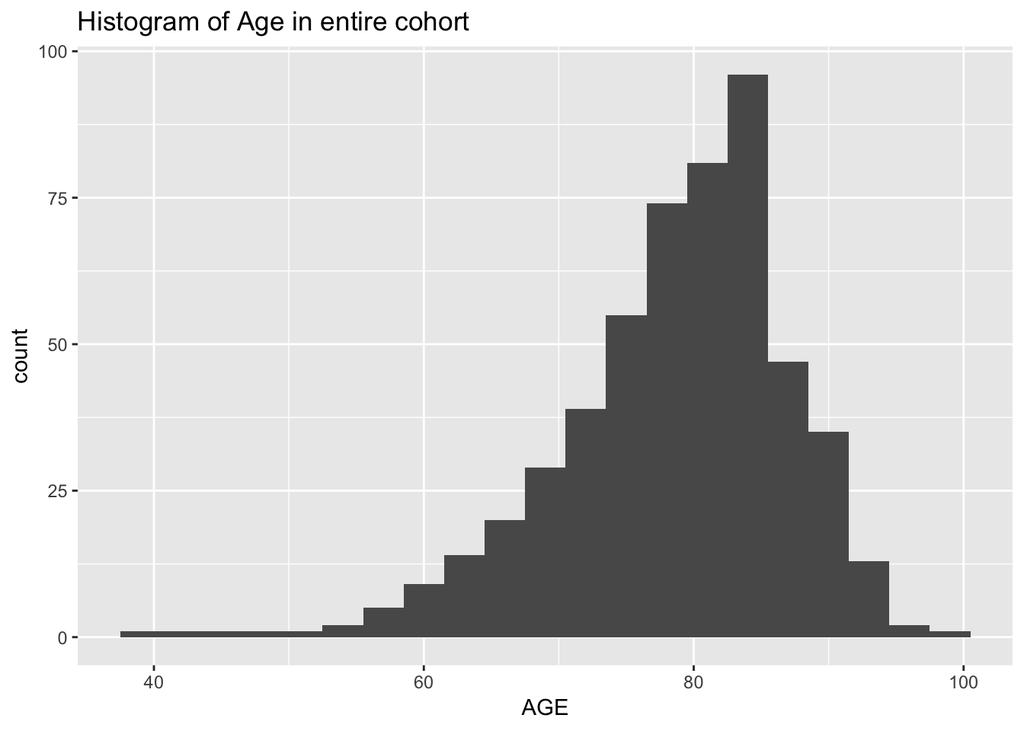

```r
#Histogram of Age
ggplot(data=NH_clean, aes(x=AGE)) +
  geom_histogram(binwidth = 3)+
  labs(title = "Histogram of Age in entire cohort")
```

```r
mean(NH_clean$HospLOS, na.rm=TRUE) #Mean Hospital LOS is 27.6 days
```

```
## [1] 27.60721
```

```r
quantile(NH_clean$HospLOS, na.rm=TRUE) #0%  25%  50%  75% 100%: 0   13   20   33  369
```

```
##   0%  25%  50%  75% 100%
##    0   13   20   33  369
```

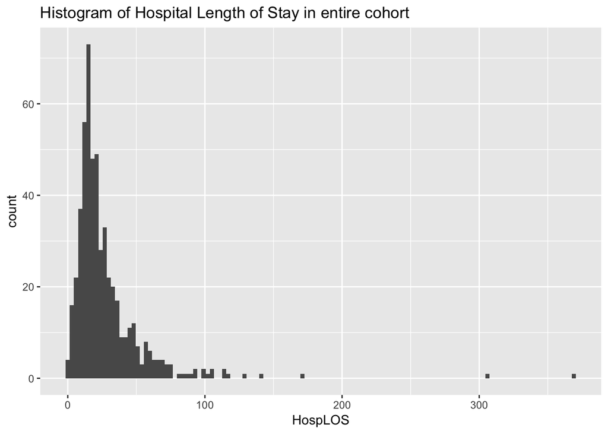

```r
#Histogram of Hospital LOS
ggplot(data=NH_clean, aes(x=HospLOS)) +
  geom_histogram(binwidth = 3)+
  labs(title = "Histogram of Hospital Length of Stay in entire cohort")
```

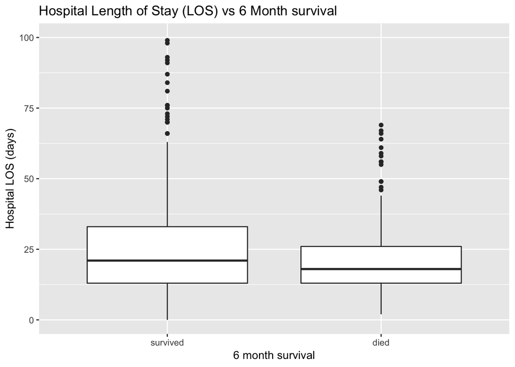

```r
#Box plot of Hosp LOS vs 6 m survival
ggplot(data=NH_clean, aes(x=factor(alive6m), y=HospLOS)) +
  geom_boxplot() +
  labs(title="Hospital Length of Stay (LOS) vs 6 Month survival") +
  labs(x=("6 month survival"), y=("Hospital LOS (days)")) +
  ylim(c(0,100))
```

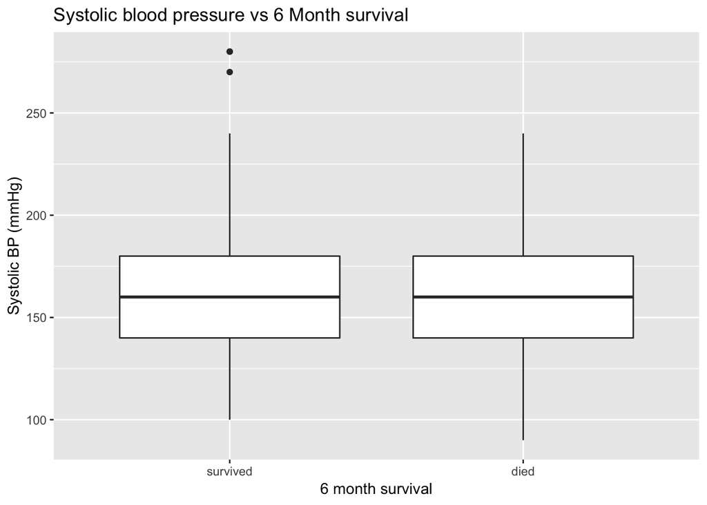

```r
#Box plot of Systolic Blood Pressure at randomization vs 6 m survival
ggplot(data=NH_clean, aes(x=factor(alive6m), y=RSBP)) +
  geom_boxplot() +
  labs(title="Systolic blood pressure vs 6 Month survival") +
  labs(y="Systolic BP (mmHg)", x=("6 month survival"))
```

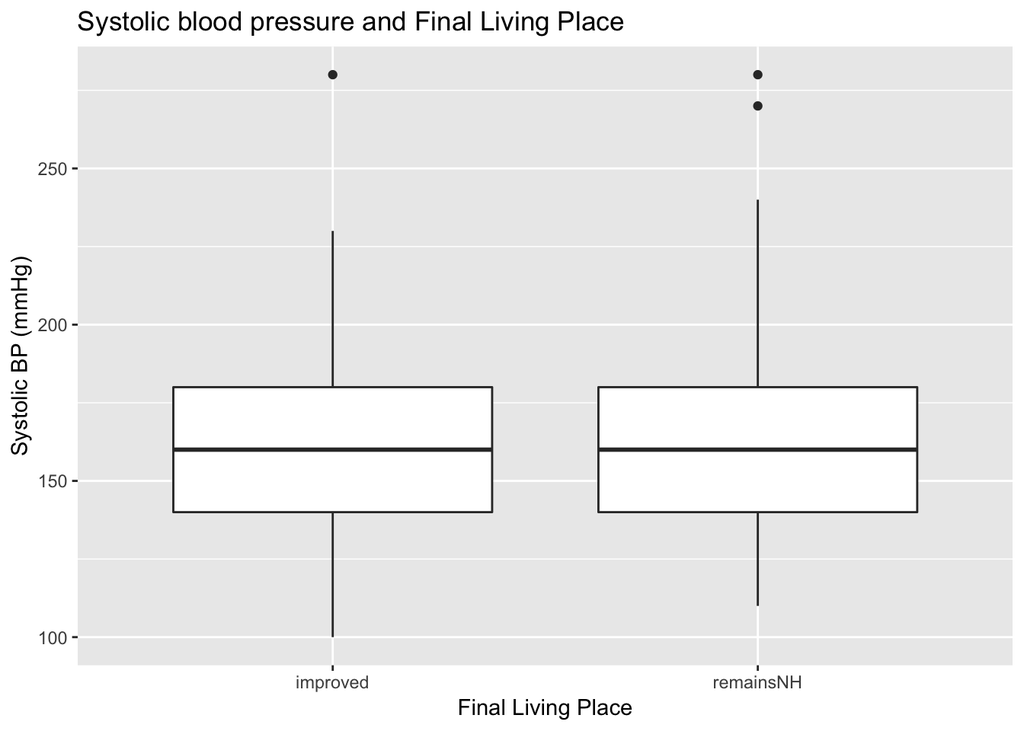

```r
#Box plot of SBP vs Final Living Place
ggplot(data=NH_FLP, aes(x=factor(FLP), y=RSBP)) +
  geom_boxplot() +
  labs(title="Systolic blood pressure and Final Living Place") +
  labs(y="Systolic BP (mmHg)", x=("Final Living Place"))
```

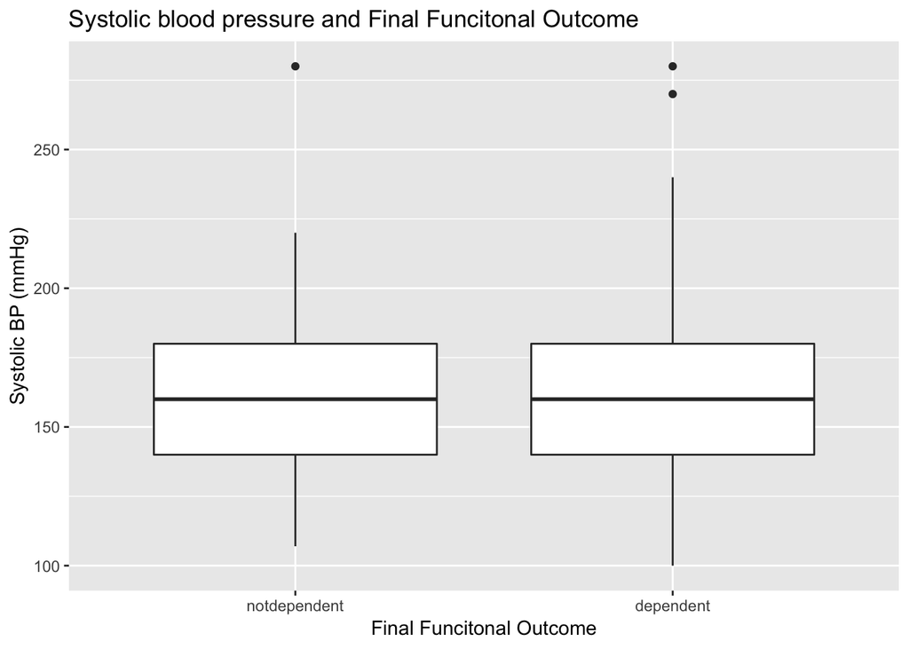

```r
#Box plot of SBP vs Final Functional Outcome
ggplot(data=NH_FFO, aes(x=factor(FFO), y=RSBP)) +
  geom_boxplot() +
  labs(title="Systolic blood pressure and Final Funcitonal Outcome") +
  labs(y="Systolic BP (mmHg)", x=("Final Funcitonal Outcome"))
```

```r
library(randomForest)
library(mlogit)
```

```r
library(ggplot2)
library(tidyverse)
library(dplyr)


#Random forests for outcome of 6 months survival of patients discharged from the hospital to a nursing home.
Alive6m.rf <- randomForest(alive6m ~ ., data=NH_alive6m, ntree=100, importance=TRUE)
Alive6m.rf
```

```
##
## Call:
##  randomForest(formula = alive6m ~ ., data = NH_alive6m, ntree = 100,      importance = TRUE)
##                Type of random forest: classification
##                      Number of trees: 100
## No. of variables tried at each split: 4
##
##         OOB estimate of  error rate: 29.79%
## Confusion matrix:
##          survived died class.error
## survived      349   37  0.09585492
## died          120   21  0.85106383
```

```r
imp.alive6m <- Alive6m.rf$importance
head(sort(imp.alive6m[,4], decreasing=TRUE), n=10)
```

```
##           AGE       HospLOS          RSBP    StrokeType        RCONSC        RSLEEP  DefDysphagia DefHemianopia     DefVisual       DefFace
##     36.678086     36.233861     28.916907     12.477517      7.498460      6.070641      5.813399      5.409919      5.108948      4.654945
```

```r
alive6m.rf.pred <- predict(Alive6m.rf, NH_alive6m, type="prob")
rf.pred.alive6m <- alive6m.rf.pred[, 2]
head(alive6m.rf.pred)
```

```
##   survived died
## 1     0.86 0.14
## 2     0.95 0.05
## 3     0.86 0.14
## 4     0.97 0.03
## 5     0.94 0.06
## 6     0.92 0.08
```

```r
#Model evaluation it K-fold Cross validation
N = nrow(NH_alive6m)
K = 10
set.seed(1234)
s = sample(1:K, size=N, replace=T)
alive6m.pred_outputs.rf <- vector(mode="numeric", length=N)
alive6m.obs_outputs <- vector(mode="numeric", length=N)
offset <- 0

for(i in 1:K){
    train <- filter(NH_alive6m, s != i)
    test <- filter(NH_alive6m, s == i)
    alive6m.obs_outputs[1:length(s[s==i]) + offset] <- test$alive6m

    #RF train/test
    rf <- randomForest(alive6m ~., data=train, ntree=100)
    rf.pred.curr <- predict(rf, newdata=test, type="prob")
    alive6m.pred_outputs.rf[1:length(s[s==i]) + offset] <- rf.pred.curr[,2]

    offset <- offset + length(s[s==i])
}


#Random forests for outcome of final Living Place of patients discharged from the hospital to the nursing home and alive at 6 months.
FLP.rf <- randomForest(FLP ~ ., data=NH_FLP, ntree=100, importance=TRUE)
FLP.rf
```

```
##
## Call:
##  randomForest(formula = FLP ~ ., data = NH_FLP, ntree = 100, importance = TRUE)
##                Type of random forest: classification
##                      Number of trees: 100
## No. of variables tried at each split: 4
##
##         OOB estimate of  error rate: 34.68%
## Confusion matrix:
##           improved remainsNH class.error
## improved       126        59   0.3189189
## remainsNH       70       117   0.3743316
```

```r
imp.FLP <- FLP.rf$importance
head(sort(imp.FLP[,4], decreasing=TRUE), n=10)
```

```
##           AGE       HospLOS          RSBP    StrokeType        RCONSC     DefVisual  DefDysphagia        RSLEEP DefHemianopia       DefFace
##     38.318484     37.934763     22.881807     12.408290      6.574321      5.739773      5.453955      4.854134      4.156786      4.150919
```

```r
FLP.rf.pred <- predict(FLP.rf, NH_FLP, type="prob")
rf.pred.FLP <- FLP.rf.pred[, 2]

#Model evaluation it K-fold Cross validation
N = nrow(NH_FLP)
K = 10
set.seed(1234)
s = sample(1:K, size=N, replace=T)
#pred_outputs.glm <- vector(mode="numeric", length=N)
FLP.pred_outputs.rf <- vector(mode="numeric", length=N)
FLP.obs_outputs <- vector(mode="numeric", length=N)
offset <- 0
for(i in 1:K){
    train <- filter(NH_FLP, s != i)
    test <- filter(NH_FLP, s == i)
    FLP.obs_outputs[1:length(s[s==i]) + offset] <- test$FLP

    #RF train/test
    rf <- randomForest(FLP ~., data=train, ntree=100)
    rf.pred.curr <- predict(rf, newdata=test, type="prob")
    FLP.pred_outputs.rf[1:length(s[s==i]) + offset] <- rf.pred.curr[,2]
    offset <- offset + length(s[s==i])
}

#Random forests for outcome of final functional outcome (FFO) of patients discharged from the hospital to the nursing home and alive at 6 months
FFO.rf <- randomForest(FFO ~ ., data=NH_FFO, ntree=100, importance=TRUE)
FFO.rf
```

```
##
## Call:
##  randomForest(formula = FFO ~ ., data = NH_FFO, ntree = 100, importance = TRUE)
##                Type of random forest: classification
##                      Number of trees: 100
## No. of variables tried at each split: 4
##
##         OOB estimate of  error rate: 19.69%
## Confusion matrix:
##              notdependent dependent class.error
## notdependent            3        66  0.95652174
## dependent              11       311  0.03416149
```

```r
imp.FFO <- FFO.rf$importance
head(sort(imp.FFO[,4], decreasing=TRUE), n=10)
```

```
##      HospLOS          AGE         RSBP   StrokeType       RSLEEP DefDysphagia       DefLeg       RCONSC      DefFace       gender
##    21.500086    18.164338    16.029922     7.852542     3.812141     3.772860     3.258709     2.510762     2.503644     2.348127
```

```r
FFO.rf.pred <- predict(FFO.rf, NH_FFO, type="prob")

#Model evaluation it K-fold Cross validation
N = nrow(NH_FFO)
K = 10
set.seed(1234)
s = sample(1:K, size=N, replace=T)
#pred_outputs.glm <- vector(mode="numeric", length=N)
FFO.pred_outputs.rf <- vector(mode="numeric", length=N)
FFO.obs_outputs <- vector(mode="numeric", length=N)
offset <- 0
for(i in 1:K){
    train <- filter(NH_FFO, s != i)
    test <- filter(NH_FFO, s == i)
    FFO.obs_outputs[1:length(s[s==i]) + offset] <- test$FFO

    #RF train/test
    rf <- randomForest(FFO ~., data=train, ntree=100)
    rf.pred.curr <- predict(rf, newdata=test, type="prob")
    FFO.pred_outputs.rf[1:length(s[s==i]) + offset] <- rf.pred.curr[,2]
    offset <- offset + length(s[s==i])
}


#Assessing all 3 models the top 4 variables are consistent: AGE, HospLOS (hospital length of stay), RSBP (first SBP at time of randomization), STYPE (stroke type). Then the next most common was def.dysphagia (dysphagia deficits)

#GLM of alive at 6 months with top variables
alive6m.top.glm <-glm(alive6m ~ AGE + HospLOS + RSBP + StrokeType + RCONSC + DefDysphagia + gender, data= NH_alive6m, family = binomial(logit))
summary(alive6m.top.glm) #Age, Stroke type:Total Anterior circulation, hospital LOS, No Dysphagia
```

```
##
## Call:
## glm(formula = alive6m ~ AGE + HospLOS + RSBP + StrokeType + RCONSC +
##     DefDysphagia + gender, family = binomial(logit), data = NH_alive6m)
##
## Deviance Residuals:
##     Min       1Q   Median       3Q      Max
## -1.5867  -0.8125  -0.5922   1.0426   2.4764
##
## Coefficients:
##                                  Estimate Std. Error z value Pr(>|z|)
## (Intercept)                     -6.677397   1.448259  -4.611 4.01e-06 ***
## AGE                              0.064621   0.015476   4.175 2.97e-05 ***
## HospLOS                         -0.012895   0.005646  -2.284  0.02238 *
## RSBP                             0.001139   0.003704   0.308  0.75836
## StrokeTypePartial Anterior Circ  0.180745   0.395481   0.457  0.64765
## StrokeTypePosterior Circ         0.529630   0.494195   1.072  0.28385
## StrokeTypeTotal Anterior Circ    1.153467   0.424142   2.720  0.00654 **
## RCONSCF                         -0.462953   0.233523  -1.982  0.04743 *
## RCONSCU                          0.445403   0.947995   0.470  0.63847
## DefDysphagiano.unk               0.562564   0.248902   2.260  0.02381 *
## genderfemale                     0.091207   0.227383   0.401  0.68834
## ---
## Signif. codes:  0 '***' 0.001 '**' 0.01 '*' 0.05 '.' 0.1 ' ' 1
##
## (Dispersion parameter for binomial family taken to be 1)
##
##     Null deviance: 612.17  on 526  degrees of freedom
## Residual deviance: 553.25  on 516  degrees of freedom
## AIC: 575.25
##
## Number of Fisher Scoring iterations: 5
```

```r
alive6m.top.glm.pred <- predict(alive6m.top.glm, NH_alive6m, type="response")


#Random forests for outcome of 6 month survival with top variables.
alive6m.top.rf <- randomForest(alive6m ~ AGE + HospLOS + RSBP + StrokeType + RCONSC + DefDysphagia + gender, data=NH_alive6m, ntree=100, importance=TRUE)
alive6m.top.rf
```

```
##
## Call:
##  randomForest(formula = alive6m ~ AGE + HospLOS + RSBP + StrokeType +      RCONSC + DefDysphagia + gender, data = NH_alive6m, ntree = 100,      importance = TRUE)
##                Type of random forest: classification
##                      Number of trees: 100
## No. of variables tried at each split: 2
##
##         OOB estimate of  error rate: 27.89%
## Confusion matrix:
##          survived died class.error
## survived      354   32  0.08290155
## died          115   26  0.81560284
```

```r
imp.alive6m.top <- alive6m.top.rf$importance
head(sort(imp.alive6m.top[,4], decreasing=TRUE), n=10)
```

```
##      HospLOS          AGE         RSBP   StrokeType       RCONSC DefDysphagia       gender
##    46.267034    45.253967    36.277388    14.817620     8.954651     6.898405     6.367166
```

```r
alive6m.top.rf.pred <- predict(alive6m.top.rf, NH_alive6m, type="prob")

#Model evaluation it K-fold Cross validation
N = nrow(NH_alive6m)
K = 10
set.seed(1234)
s = sample(1:K, size=N, replace=T)
alive6m.top.pred_outputs.glm <- vector(mode="numeric", length=N)
alive6m.top.pred_outputs.rf <- vector(mode="numeric", length=N)
alive6m.top.obs_outputs <- vector(mode="numeric", length=N)
offset <- 0
for(i in 1:K){
    train <- filter(NH_alive6m, s != i)
    test <- filter(NH_alive6m, s == i)
    alive6m.top.obs_outputs[1:length(s[s==i]) + offset] <- test$alive6m
   #GLM train/test
    glm <- glm(alive6m ~ AGE + HospLOS + RSBP + StrokeType + RCONSC + DefDysphagia + gender, data=train, family=binomial(logit))
    glm.pred.curr <- predict(glm, test, type="response")
    alive6m.top.pred_outputs.glm[1:length(s[s==i]) + offset] <- glm.pred.curr

    #RF train/test
    rf <- randomForest(alive6m ~ AGE + HospLOS + RSBP + StrokeType + RCONSC + DefDysphagia + gender, data=train, ntree=100)
    rf.pred.curr <- predict(rf, newdata=test, type="prob")
    alive6m.top.pred_outputs.rf[1:length(s[s==i]) + offset] <- rf.pred.curr[,2]

    offset <- offset + length(s[s==i])
}

#GLM of Final Living Place with top variables
FLP.top.glm <-glm(FLP ~ AGE + HospLOS + RSBP + StrokeType + RCONSC + DefDysphagia + gender, data= NH_FLP, family = binomial(logit))
summary(FLP.top.glm) #Age, stroke type(total anterior circulation), hospital LOS, No dysphagia
```

```
##
## Call:
## glm(formula = FLP ~ AGE + HospLOS + RSBP + StrokeType + RCONSC +
##     DefDysphagia + gender, family = binomial(logit), data = NH_FLP)
##
## Deviance Residuals:
##     Min       1Q   Median       3Q      Max
## -2.4787  -1.0162   0.3385   0.9797   2.2265
##
## Coefficients:
##                                  Estimate Std. Error z value Pr(>|z|)
## (Intercept)                     -8.463728   1.555735  -5.440 5.32e-08 ***
## AGE                              0.092413   0.016662   5.546 2.92e-08 ***
## HospLOS                          0.009344   0.004683   1.995 0.046015 *
## RSBP                             0.001910   0.004107   0.465 0.641983
## StrokeTypePartial Anterior Circ  0.732078   0.387670   1.888 0.058971 .
## StrokeTypePosterior Circ         0.008472   0.542976   0.016 0.987551
## StrokeTypeTotal Anterior Circ    1.612168   0.453366   3.556 0.000377 ***
## RCONSCF                         -0.520055   0.275029  -1.891 0.058637 .
## RCONSCU                         -0.410627   1.261470  -0.326 0.744791
## DefDysphagiano.unk               0.627188   0.289510   2.166 0.030282 *
## genderfemale                    -0.147634   0.250671  -0.589 0.555892
## ---
## Signif. codes:  0 '***' 0.001 '**' 0.01 '*' 0.05 '.' 0.1 ' ' 1
##
## (Dispersion parameter for binomial family taken to be 1)
##
##     Null deviance: 515.69  on 371  degrees of freedom
## Residual deviance: 437.72  on 361  degrees of freedom
## AIC: 459.72
##
## Number of Fisher Scoring iterations: 4
```

```r
FLP.top.glm.pred <- predict(FLP.top.glm, NH_FLP, type="response")


#Random forests for outcome of final Living Place with top variables.
FLP.top.rf <- randomForest(FLP ~ AGE + HospLOS + RSBP + StrokeType + RCONSC + DefDysphagia + gender, data=NH_FLP, ntree=100, importance=TRUE)
FLP.top.rf
```

```
##
## Call:
##  randomForest(formula = FLP ~ AGE + HospLOS + RSBP + StrokeType +      RCONSC + DefDysphagia + gender, data = NH_FLP, ntree = 100,      importance = TRUE)
##                Type of random forest: classification
##                      Number of trees: 100
## No. of variables tried at each split: 2
##
##         OOB estimate of  error rate: 34.95%
## Confusion matrix:
##           improved remainsNH class.error
## improved       114        71   0.3837838
## remainsNH       59       128   0.3155080
```

```r
imp.FLP <- FLP.top.rf$importance
head(sort(imp.FLP[,4], decreasing=TRUE), n=10)
```

```
##      HospLOS          AGE         RSBP   StrokeType DefDysphagia       RCONSC       gender
##    49.259842    47.007166    26.549508    16.743588     7.199413     6.947083     6.196008
```

```r
FLP.top.rf.pred <- predict(FLP.rf, NH_FLP, type="prob")

#Model evaluation it K-fold Cross validation
N = nrow(NH_FLP)
K = 10
set.seed(1234)
s = sample(1:K, size=N, replace=T)
FLP.top.pred_outputs.glm <- vector(mode="numeric", length=N)
FLP.top.pred_outputs.rf <- vector(mode="numeric", length=N)
FLP.top.obs_outputs <- vector(mode="numeric", length=N)
offset <- 0
for(i in 1:K){
    train <- filter(NH_FLP, s != i)
    test <- filter(NH_FLP, s == i)
    FLP.top.obs_outputs[1:length(s[s==i]) + offset] <- test$FLP

    #GLM train/test
    glm <- glm(FLP ~ AGE + HospLOS + RSBP + StrokeType + RCONSC + DefDysphagia + gender, data=train, family=binomial(logit))
    glm.pred.curr <- predict(glm, test, type="response")
    FLP.top.pred_outputs.glm[1:length(s[s==i]) + offset] <- glm.pred.curr

    #RF train/test
    rf <- randomForest(FLP ~ AGE + HospLOS + RSBP + StrokeType + RCONSC + DefDysphagia + gender, data=train, ntree=100)
    rf.pred.curr <- predict(rf, newdata=test, type="prob")
    FLP.top.pred_outputs.rf[1:length(s[s==i]) + offset] <- rf.pred.curr[,2]

    offset <- offset + length(s[s==i])
}


#GLM of Final Functional Outcome with top variables
FFO.top.glm <-glm(FFO ~ AGE + HospLOS + RSBP + StrokeType + RCONSC + DefDysphagia + gender, data= NH_FFO, family = binomial(logit))
summary(FFO.top.glm) #Hosp length of stay + Stroke type (Total anterior circulation)
```

```
##
## Call:
## glm(formula = FFO ~ AGE + HospLOS + RSBP + StrokeType + RCONSC +
##     DefDysphagia + gender, family = binomial(logit), data = NH_FFO)
##
## Deviance Residuals:
##     Min       1Q   Median       3Q      Max
## -2.6972   0.2493   0.4226   0.6735   1.3941
##
## Coefficients:
##                                   Estimate Std. Error z value Pr(>|z|)
## (Intercept)                      -1.860540   1.540855  -1.207  0.22725
## AGE                               0.023418   0.015797   1.482  0.13824
## HospLOS                           0.024780   0.009787   2.532  0.01134 *
## RSBP                              0.001974   0.005149   0.383  0.70143
## StrokeTypePartial Anterior Circ   0.614428   0.449540   1.367  0.17169
## StrokeTypePosterior Circ         -0.621763   0.515081  -1.207  0.22739
## StrokeTypeTotal Anterior Circ     1.696004   0.588837   2.880  0.00397 **
## RCONSCF                          -0.474671   0.392042  -1.211  0.22599
## RCONSCU                          12.765998 814.549811   0.016  0.98750
## DefDysphagiano.unk                0.522647   0.378686   1.380  0.16754
## genderfemale                      0.301982   0.304889   0.990  0.32195
## ---
## Signif. codes:  0 '***' 0.001 '**' 0.01 '*' 0.05 '.' 0.1 ' ' 1
##
## (Dispersion parameter for binomial family taken to be 1)
##
##     Null deviance: 364.41  on 390  degrees of freedom
## Residual deviance: 316.82  on 380  degrees of freedom
## AIC: 338.82
##
## Number of Fisher Scoring iterations: 14
```

```r
FFO.top.glm.pred <- predict(FFO.top.glm, NH_FFO, type="response")

#Random forests for outcome of Final functional outcome with top variables.
FFO.top.rf <- randomForest(FFO ~ AGE + HospLOS + RSBP + StrokeType + RCONSC + DefDysphagia + gender, data=NH_FFO, ntree=100, importance=TRUE)
FFO.top.rf
```

```
##
## Call:
##  randomForest(formula = FFO ~ AGE + HospLOS + RSBP + StrokeType +      RCONSC + DefDysphagia + gender, data = NH_FFO, ntree = 100,      importance = TRUE)
##                Type of random forest: classification
##                      Number of trees: 100
## No. of variables tried at each split: 2
##
##         OOB estimate of  error rate: 20.72%
## Confusion matrix:
##              notdependent dependent class.error
## notdependent            2        67  0.97101449
## dependent              14       308  0.04347826
```

```r
imp.FFO <- FFO.top.rf$importance
head(sort(imp.FFO[,4], decreasing=TRUE), n=10)
```

```
##      HospLOS          AGE         RSBP   StrokeType DefDysphagia       gender       RCONSC
##    28.435252    23.381846    19.728193    10.687474     4.644593     3.477828     2.734188
```

```r
FFO.top.rf.pred <- predict(FFO.rf, NH_FFO, type="prob")

#Model evaluation it K-fold Cross validation
N = nrow(NH_FFO)
K = 10
set.seed(1234)
s = sample(1:K, size=N, replace=T)
FFO.top.pred_outputs.glm <- vector(mode="numeric", length=N)
FFO.top.pred_outputs.rf <- vector(mode="numeric", length=N)
FFO.top.obs_outputs <- vector(mode="numeric", length=N)
offset <- 0
for(i in 1:K){
    train <- filter(NH_FFO, s != i)
    test <- filter(NH_FFO, s == i)
    FFO.top.obs_outputs[1:length(s[s==i]) + offset] <- test$FFO

    #GLM train/test
    glm <- glm(FFO ~ AGE + HospLOS + RSBP + StrokeType + RCONSC + DefDysphagia + gender, data=train, family=binomial(logit))
    glm.pred.curr <- predict(glm, test, type="response")
    FFO.top.pred_outputs.glm[1:length(s[s==i]) + offset] <- glm.pred.curr

    #RF train/test
    rf <- randomForest(FFO ~ AGE + HospLOS + RSBP + StrokeType + RCONSC + DefDysphagia + gender, data=train, ntree=100)
    rf.pred.curr <- predict(rf, newdata=test, type="prob")
    FFO.top.pred_outputs.rf[1:length(s[s==i]) + offset] <- rf.pred.curr[,2]

    offset <- offset + length(s[s==i])
}
```

### Results

#### Model Evaulation:

##### 6 month Survival

All models predicting 6 month survival had a moderate to fair performance (Figure 4a,4b)(Table 2). The Logistic Regression model using top variables performed slightly better than other models with an AUC of 0.67. There is evidence for overfitting in both models of random forests as shown by the large difference between the AUC of the training versus testing data. Age, Total Anterior Stroke, No/Unknown Dysphagia were all significantly associated with increase chance of dying, while increased hospital length of stay and full consciousness at time of randomization where significantly associated with surviving at 6 months. Table 3 shows the p values for these variables.

##### Final Living Place

All models predicting 6 month survival had moderate performance (Figure 5a,5b)(Table 4). The Logistic Regression model using top variables again performed slightly better than other models with an AUC of 0.7135. There is evidence for overfitting in both models of random forests as shown by the large difference between the AUC of the training versus testing data. Age, hospital length of stay, total anterior stroke, no/unknown dysphagia were all significantly associated with remaining in a nursing home in the logistic regression model (Table 5).

##### Final Functional OUtcome

All models predicting 6 month survival had a moderate to fair performance (Figure 6a,6b)(Table 6). The Logistic Regression model using top variables again performed slightly better than other models with an AUC of 0.71. There is evidence for overfitting in both models of random forests as shown by the large difference between the AUC of the training versus testing data. Increased hospital length of stay and total anterior stroke were both significantly associated with being in a dependent state in the logistic regression model (Table 7).

### Conclusions

For ischemic stroke patients who are discharged to a nursing home after a stroke were able to develop prediction models for 6 month outcomes of survival, final living place and functional outcome. For all outcomes the logistic regression models using top variables slightly outperformed the other models. Considering the multitude of factors the subjects are exposed to between hospital discharge and 6 month outcomes, it would be very difficult to have a highly predictive model using only in-hospital variables. We therefor are satisfied with the moderate performance of our models. Future directions would be to apply and test this model on future stroke populations that were not able to receive thrombectomy or thrombolysis.

```r
library(pROC)
library(dplyr)

#Descriptive Statistics

#First make table of all outcomes and how many subjects are in each
Count_alive6m <- Count_alive6m %>%
  rename(Outcome=alive6m) %>%
  select(Outcome, n)
Count_FLP <- Count_FLP %>%
  rename(Outcome=FLP) %>%
  select(Outcome, n)
Count_FFO <- Count_FFO %>%
  rename(Outcome=FFO) %>%
  select(Outcome, n)

Table1 <- data.frame(rbind(Count_alive6m, Count_FFO, Count_FLP, deparse.level = 1, make.row.names = TRUE, stringsAsFactors = default.stringsAsFactors()))
Table1
```

```
##        Outcome   n
## 1     survived 386
## 2         died 141
## 3 notdependent  69
## 4    dependent 322
## 5     improved 185
## 6    remainsNH 187
```

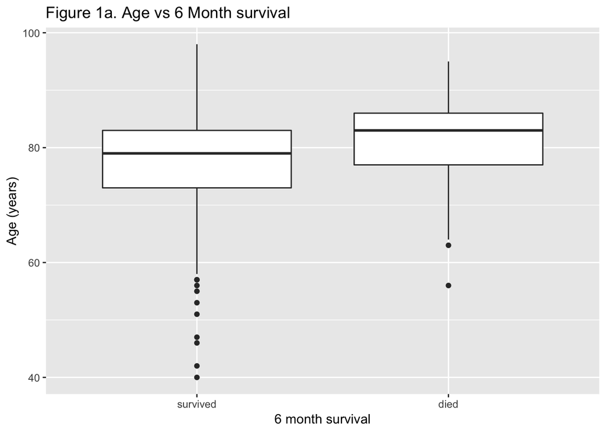

```r
#Figure 1: BoxPlots of Age vs outcomes
#Figure 1a.Box plot of Age vs 6 m survival
ggplot(data=NH_clean, aes(x=factor(alive6m), y=AGE)) +
  geom_boxplot() +
  labs(title="Figure 1a. Age vs 6 Month survival") +
  labs(y="Age (years)", x=("6 month survival"))
```

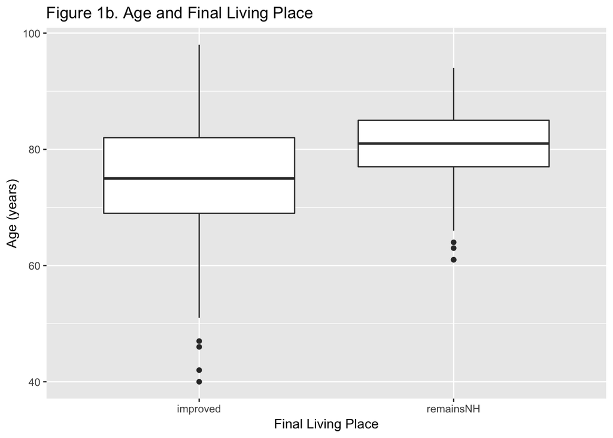

```r
#Figure 1b. Box plot of Age vs Final Living Place
ggplot(data=NH_FLP, aes(x=factor(FLP), y=AGE)) +
  geom_boxplot() +
  labs(title="Figure 1b. Age and Final Living Place") +
  labs(y="Age (years)", x=("Final Living Place"))
```

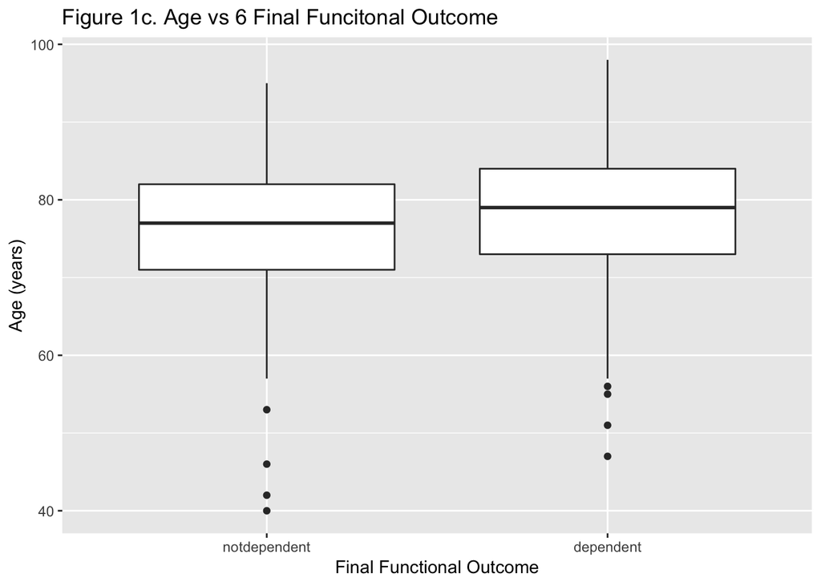

```r
#Figure 1c. Box plot of Age vs Final Functional Outcome
ggplot(data=NH_FFO, aes(x=factor(FFO), y=AGE)) +
  geom_boxplot() +
  labs(title="Figure 1c. Age vs 6 Final Funcitonal Outcome") +
  labs(y="Age (years)", x=("Final Functional Outcome"))
```

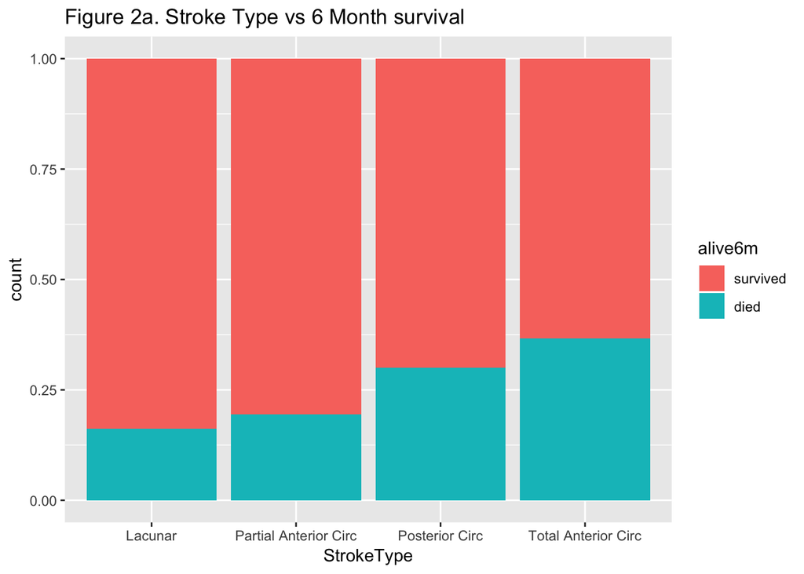

```r
#Figure 2: Stroke Type vs Outcomes
#Figure 2a. Box plot of Stroke type and survival
ggplot(data=NH_alive6m, aes(x=StrokeType, fill=alive6m)) +
  geom_bar(position="fill") +
  labs(title="Figure 2a. Stroke Type vs 6 Month survival")
```

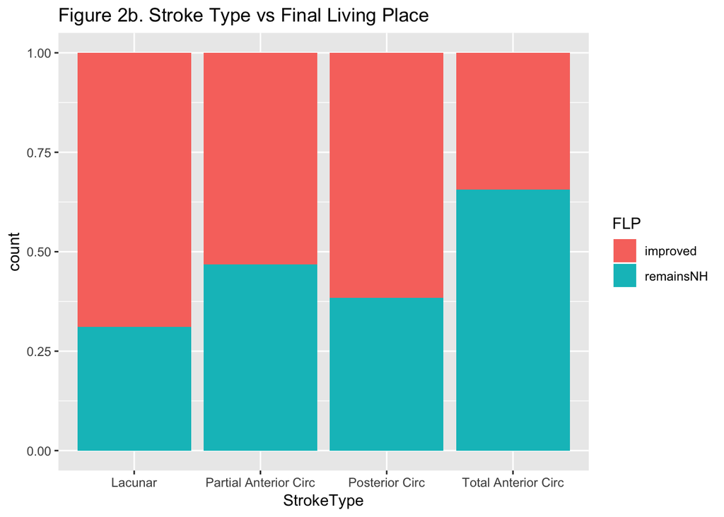

```r
#Figure 2b. Box plot of Stroke type and Final Living Place
ggplot(data=NH_FLP, aes(x=StrokeType, fill=FLP)) +
  geom_bar(position="fill") +
  labs(title="Figure 2b. Stroke Type vs Final Living Place")
```

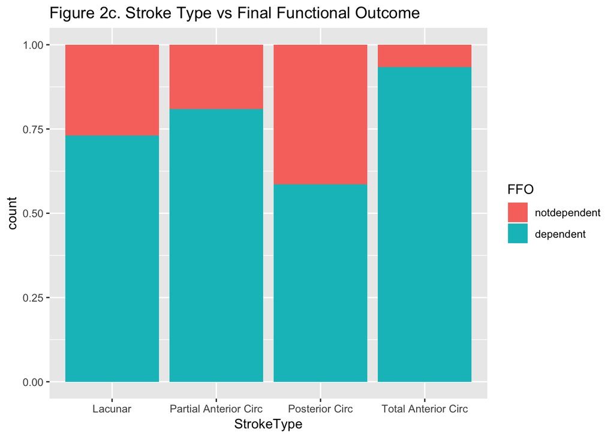

```r
#Figure 2c. Box plot of Stroke Type and Final Functional Outcome
ggplot(data=NH_FFO, aes(x=StrokeType, fill=FFO)) +
  geom_bar(position="fill") +
  labs(title="Figure 2c. Stroke Type vs Final Functional Outcome")
```

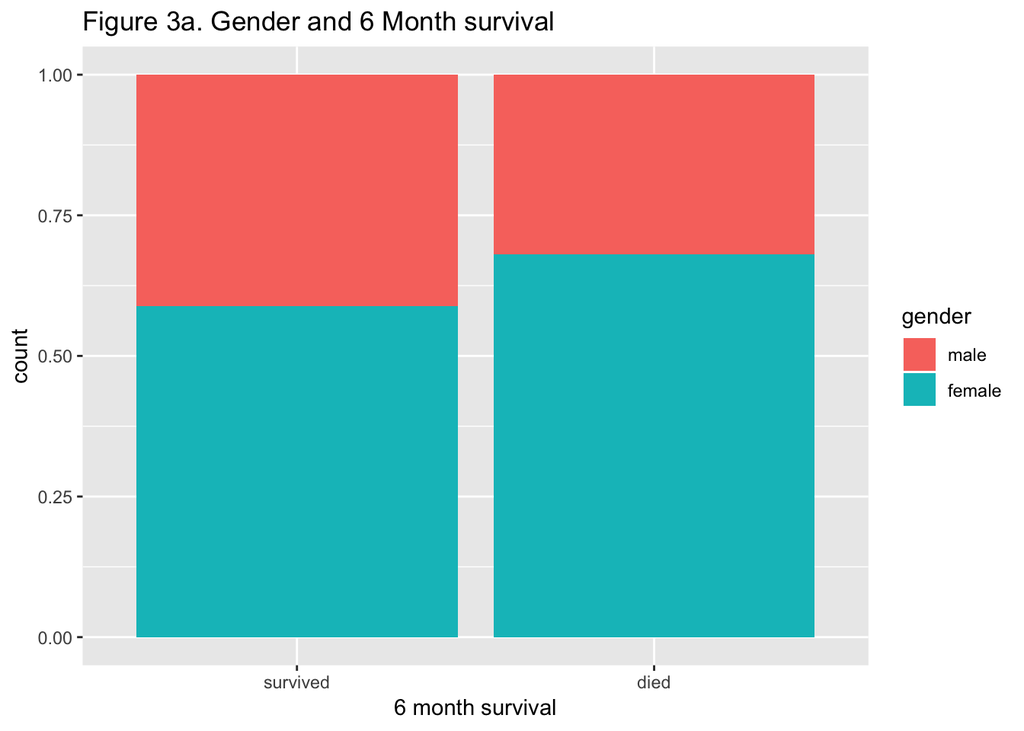

```r
#Figure 3. Gender vs Outcomes
#Figure 3a. Box plot of gender and survival
ggplot(data=NH_alive6m, aes(x=alive6m, fill=gender)) +
  geom_bar(position="fill") +
  labs(title="Figure 3a. Gender and 6 Month survival") +
  labs(x="6 month survival")
```

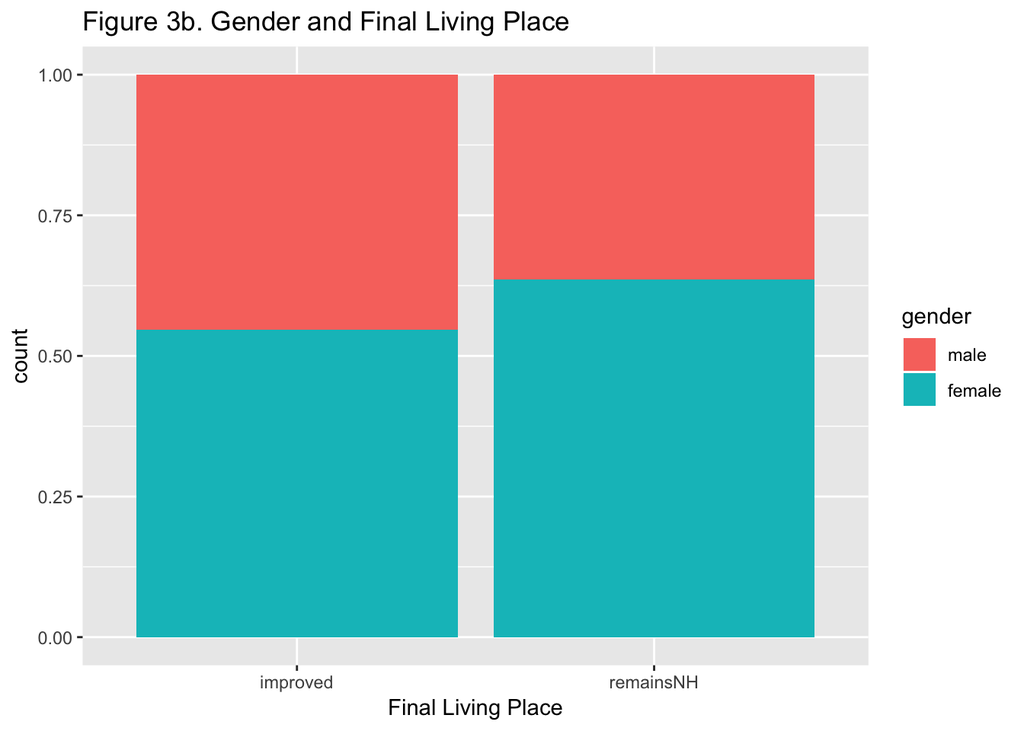

```r
#Figure 3b. Box plot of gender and Final Living Place
ggplot(data=NH_FLP, aes(x=FLP, fill=gender)) +
  geom_bar(position="fill") +
   labs(title="Figure 3b. Gender and Final Living Place") +
  labs(x="Final Living Place")
```

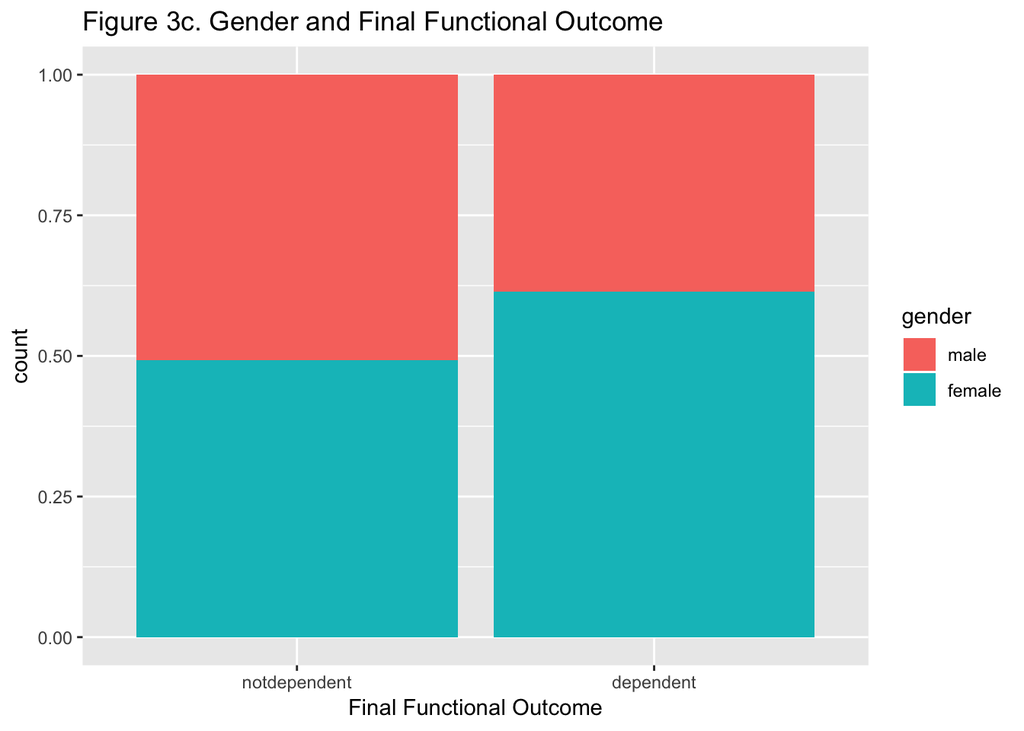

```r
#Figure 3c. Box plot of gender and Final Functional Outcome
ggplot(data=NH_FFO, aes(x=FFO, fill=gender)) +
  geom_bar(position="fill") +
   labs(title="Figure 3c. Gender and Final Functional Outcome") +
  labs(x="Final Functional Outcome")
```

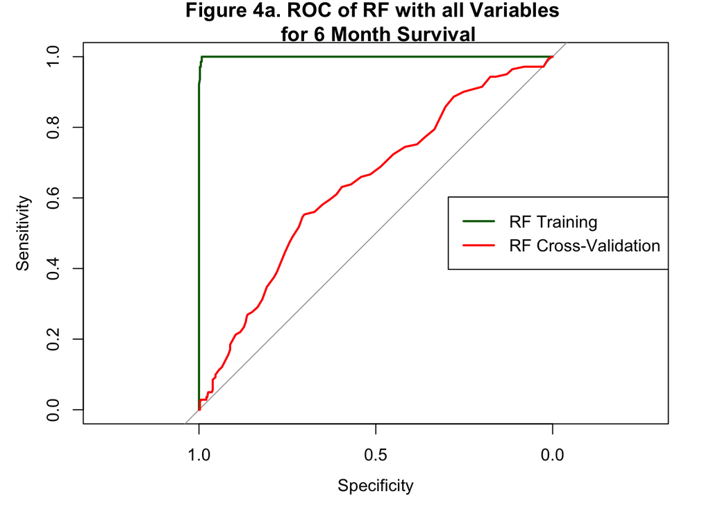

```r
#Figure 4a. ROC curves of RF with all Variables for 6 Month Survival
pROC::plot.roc(NH_alive6m$alive6m, rf.pred.alive6m, ci=TRUE, main="Figure 4a. ROC of RF with all Variables \n for 6 Month Survival", col="darkgreen", add=FALSE)
pROC::plot.roc(alive6m.obs_outputs, alive6m.pred_outputs.rf, ci=TRUE, col="red", add=TRUE)
legend("right", legend=c("RF Training", "RF Cross-Validation"), col=c("darkgreen", "red"), lwd=2)
```

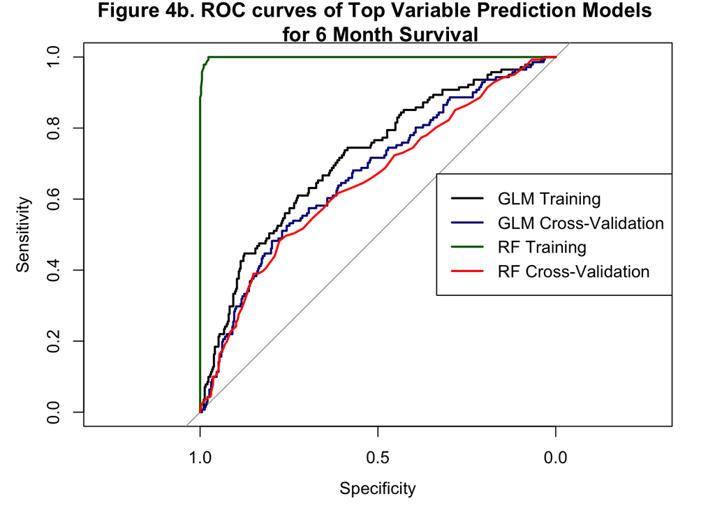

```r
#Figure 4b. ROC curves of alive 6 m with top variables
plot.roc(NH_alive6m$alive6m, alive6m.top.glm.pred, ci+TRUE, main="Figure 4b. ROC curves of Top Variable Prediction Models \n for 6 Month Survival")
plot.roc(alive6m.top.obs_outputs, alive6m.top.pred_outputs.glm, ci+TRUE, col="darkblue", add = TRUE)
plot.roc(NH_alive6m$alive6m, alive6m.top.rf.pred[,2], ci=TRUE, col="darkgreen", add=TRUE)
plot.roc(alive6m.top.obs_outputs, alive6m.top.pred_outputs.rf, ci=TRUE, col="red", add=TRUE)
legend("right", legend=c("GLM Training", "GLM Cross-Validation", "RF Training", "RF Cross-Validation"), col=c("black", "darkblue", "darkgreen", "red"), lwd=2)
```

```r
#Table 2: AUC for Models predicting 6 month survival
Model_6month_survival <- list("RF with all variables", "RF with Top Predictors", "GLM with Top Predictors")
AUC <- list((auc(alive6m.obs_outputs, alive6m.pred_outputs.rf)), (auc(alive6m.top.obs_outputs, alive6m.top.pred_outputs.rf)), (auc(alive6m.top.obs_outputs, alive6m.top.pred_outputs.glm)))
Table2 <- cbind(Model_6month_survival, AUC)
Table2 #Table2: Comparison of AUC for each Prediction Model for 6 Month Survival
```

```
##      Model_6month_survival     AUC
## [1,] "RF with all variables"   0.6390604
## [2,] "RF with Top Predictors"  0.6496987
## [3,] "GLM with Top Predictors" 0.6699372
```

```r
#Table 3: Variables with significant p values for 6 month survival
Variable <- list("Age", "Hospital Length of Stay", "Total Anterior Stroke", "No/Unknown Dysphagia", "Full Consciousness at randomization")
PValue <- list(3e-05, 0.022, 0.007, 0.024, 0.047)
Table3 <- cbind(Variable, PValue)
Table3 #Table 3: Variables with significant p values for 6 month survival
```

```
##      Variable                              PValue
## [1,] "Age"                                 3e-05
## [2,] "Hospital Length of Stay"             0.022
## [3,] "Total Anterior Stroke"               0.007
## [4,] "No/Unknown Dysphagia"                0.024
## [5,] "Full Consciousness at randomization" 0.047
```

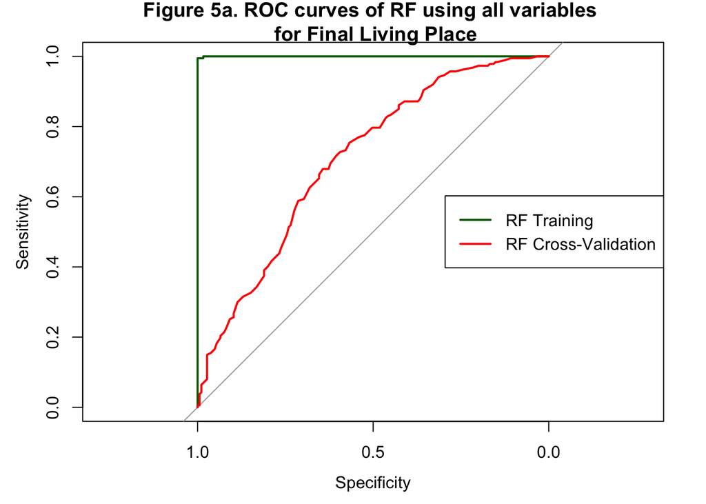

```r
#Figure 5a. ROC curves of RF using all variables for Final Living Place
plot.roc(NH_FLP$FLP, FLP.rf.pred[,2], ci=TRUE, main="Figure 5a. ROC curves of RF using all variables \n for Final Living Place", col="darkgreen", add=FALSE)
plot.roc(FLP.obs_outputs, FLP.pred_outputs.rf, ci=TRUE, col="red", add=TRUE)
legend("right", legend=c("RF Training", "RF Cross-Validation"), col=c("darkgreen", "red"), lwd=2)
```

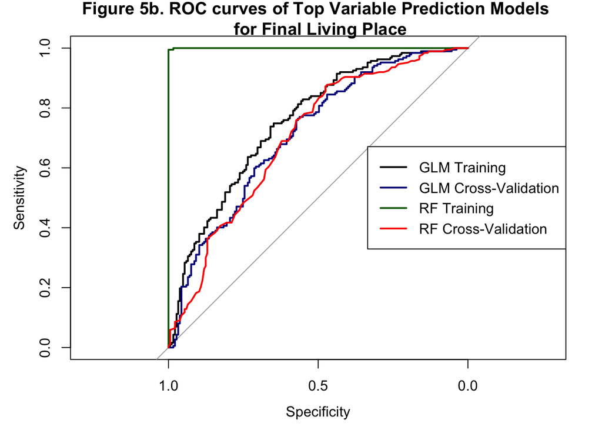

```r
#Figure 5b. ROC curves of RF and GLM predictors of Final Living Place (FLP) with top variables
plot.roc(NH_FLP$FLP, FLP.top.glm.pred, ci=TRUE, main="Figure 5b. ROC curves of Top Variable Prediction Models \n for Final Living Place")
plot.roc(FLP.top.obs_outputs, FLP.top.pred_outputs.glm, ci=TRUE, col="darkblue", add=TRUE)
plot.roc(NH_FLP$FLP, FLP.top.rf.pred[,2], ci=TRUE, col="darkgreen", add=TRUE)
plot.roc(FLP.top.obs_outputs, FLP.top.pred_outputs.rf, ci=TRUE, col="red", add=TRUE)
legend("right", legend=c("GLM Training", "GLM Cross-Validation", "RF Training", "RF Cross-Validation"), col=c("black", "darkblue", "darkgreen", "red"), lwd=2)
```

```r
#Table 4: AUC for Final Living Place Models
Model_FLP <- list("RF with all variables", "RF with Top Predictors", "GLM with Top Predictors")
AUC <- list((auc(FLP.obs_outputs, FLP.pred_outputs.rf)), (auc(FLP.top.obs_outputs, FLP.top.pred_outputs.rf)), (auc(FLP.top.obs_outputs, FLP.top.pred_outputs.glm)))
Table4 <- cbind(Model_FLP, AUC)
Table4 #Table4: Comparison of AUC for each Prediction Model for Final Living Place
```

```
##      Model_FLP                 AUC
## [1,] "RF with all variables"   0.7082093
## [2,] "RF with Top Predictors"  0.7028328
## [3,] "GLM with Top Predictors" 0.7135135
```

```r
#Table 5: Variables with significant p values for Final Living Place
FLP_Sig_Variable <- list("Age", "Hospital Length of Stay", "Total Anterior Stroke", "No/Unknown Dysphagia")
PValue <- list(3e-08, 0.046, 0.0004, 0.03)
Table5 <- cbind(FLP_Sig_Variable, PValue)
Table5 #Table 5: Variables with significant p values for Final Living Place
```

```
##      FLP_Sig_Variable          PValue
## [1,] "Age"                     3e-08
## [2,] "Hospital Length of Stay" 0.046
## [3,] "Total Anterior Stroke"   4e-04
## [4,] "No/Unknown Dysphagia"    0.03
```

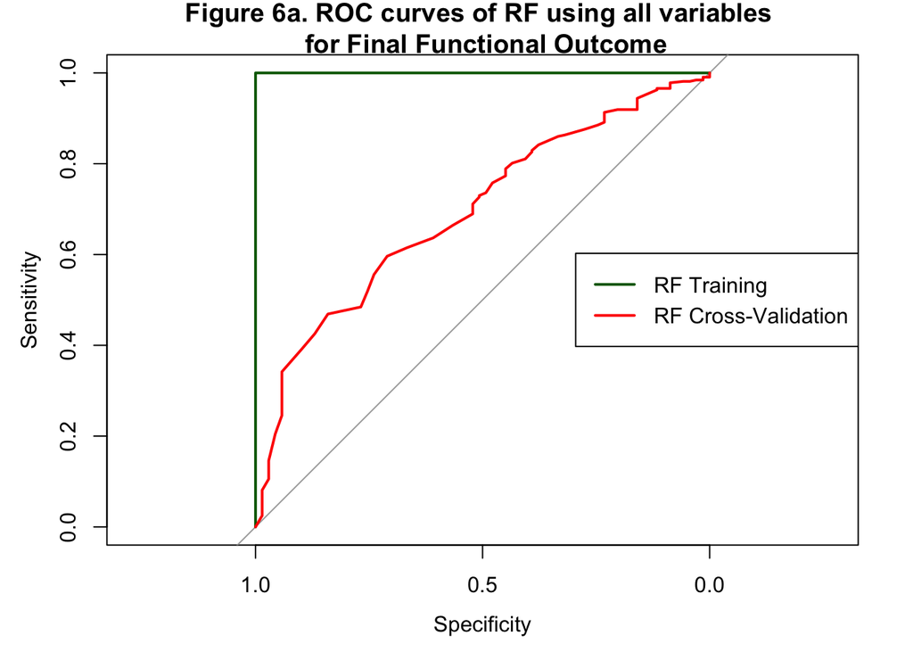

```r
#Figure 6a. ROC curves of RF using all variables for Final Functional Outcome
plot.roc(NH_FFO$FFO, FFO.rf.pred[,2], ci=TRUE, main="Figure 6a. ROC curves of RF using all variables \n for Final Functional Outcome", col="darkgreen", add=FALSE)
plot.roc(FFO.obs_outputs, FFO.pred_outputs.rf, ci=TRUE, col="red", add=TRUE)
legend("right", legend=c("RF Training", "RF Cross-Validation"), col=c("darkgreen", "red"), lwd=2)
```

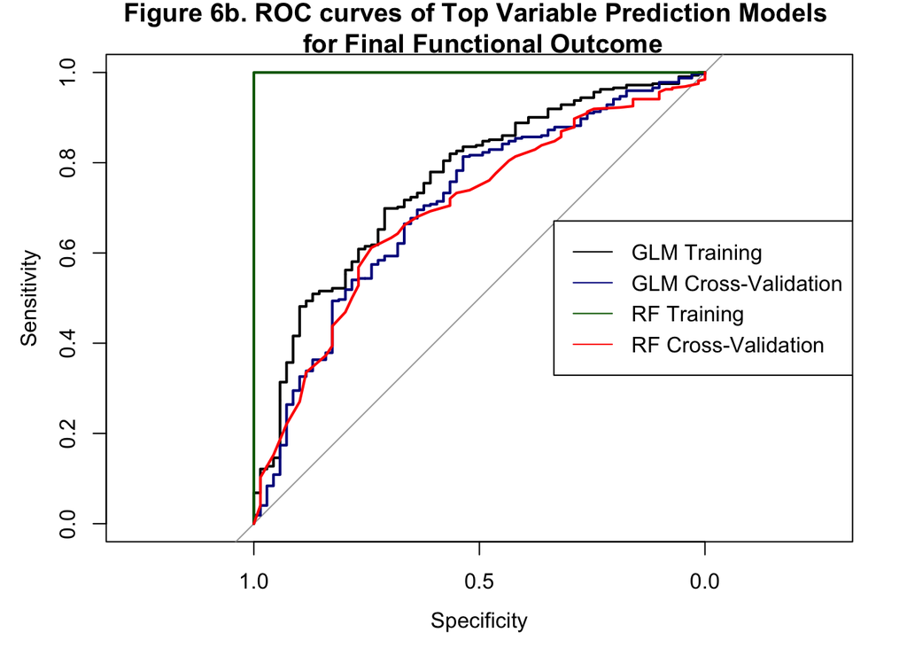

```r
#Figure 6b. RF and GLM Prediction Model ROC curves for Final Functional Outcome
plot.roc(NH_FFO$FFO, FFO.top.glm.pred, ci=TRUE, main="Figure 6b. ROC curves of Top Variable Prediction Models \n for Final Functional Outcome")
plot.roc(FFO.top.obs_outputs, FFO.top.pred_outputs.glm, ci=TRUE, col="darkblue", add=TRUE)
plot.roc(NH_FFO$FFO, FFO.top.rf.pred[,2], ci=TRUE, col="darkgreen", add=TRUE)
plot.roc(FFO.top.obs_outputs, FFO.top.pred_outputs.rf, ci=TRUE, col="red", add=TRUE)
legend("right", legend=c("GLM Training", "GLM Cross-Validation", "RF Training", "RF Cross-Validation"), col=c("black", "darkblue", "darkgreen", "red"), lwd=1)
```

```r
#Table 6: AUC for Final Functional Outcome (FFO) Models
Model_FFO <- list("RF with all variables", "RF with Top Predictors", "GLM with Top Predictors")
AUC <- list((auc(FFO.obs_outputs, FFO.pred_outputs.rf)), (auc(FFO.top.obs_outputs, FFO.top.pred_outputs.rf)), (auc(FFO.top.obs_outputs, FFO.top.pred_outputs.glm)))
Table6 <- cbind(Model_FFO, AUC)
Table6 #Table6: Comparison of AUC for each Prediction Model for Final Functional Outcome
```

```
##      Model_FFO                 AUC
## [1,] "RF with all variables"   0.694752
## [2,] "RF with Top Predictors"  0.6947295
## [3,] "GLM with Top Predictors" 0.7065893
```

```r
#Table 7: Variables with significant p values for Final Functional Outcome
FFO_Sig_Variable <- list("Hospital Length of Stay", "Total Anterior Stroke")
PValue <- list(0.011, 0.004)
Table7 <- cbind(FFO_Sig_Variable, PValue)
Table7 #Table 7: Variables with significant p values for Final Functional Outcome
```

```
##      FFO_Sig_Variable          PValue
## [1,] "Hospital Length of Stay" 0.011
## [2,] "Total Anterior Stroke"   0.004
```